# The Evolution of Alternate Photosynthetic Pathways

## Atmospheric CO<sub>2</sub> varies across geologic time

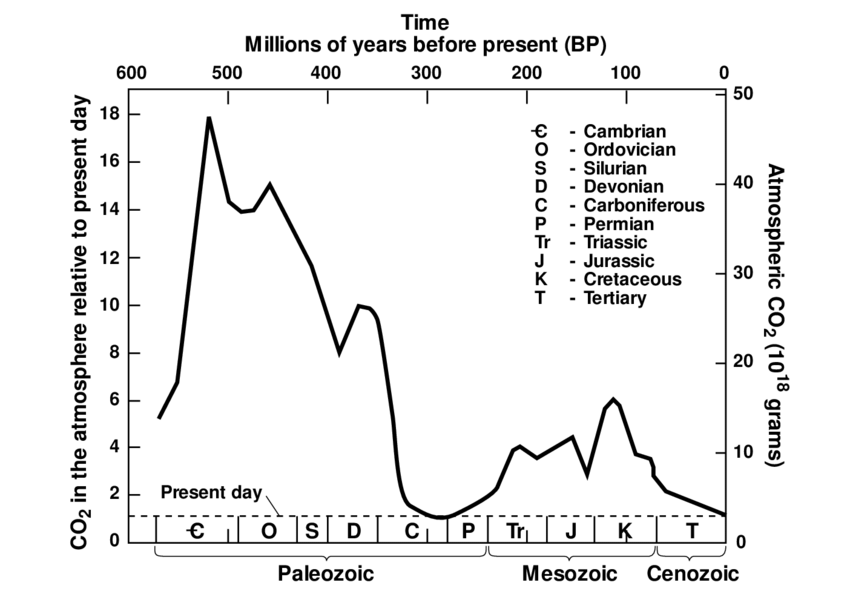

- **CO<sub>2</sub> ranged 180 - 4000 ppm in last 500 million years**
- **The photorespiration problem was not as bad 500mya when life comes on to land**
  - the drawdown of CO<sub>2</sub> starting when land plants evolve is pretty clear
- **Large decline in CO<sub>2</sub> last 30 million years**
- **O<sub>2</sub> levels started increasing (from 10%) starting 500 mya**
  - What does this mean for the current efficiency of C3 photosynthesis?

## New photosynthetic pathways evolved recently (~30 mya)

- **Rubisco has existed for billions of years**
  - evolved when O<sub>2</sub> was negligible in the atmosphere
  - mutations have yet to produce a superior version of the enzyme for the environment to select
- **Plants can do nothing about CO<sub>2</sub> nor 0<sub>2</sub> concentrations in the air**
- **C3 plants keep stomata open during the data, allowing gas exchange, while losing H<sub>2</sub>0**
  - balance of CO<sub>2</sub> in, H<sub>2</sub>O out is poor due to rubisco

**Alternative solution 1: Compartmentalize rubisco and concentrate CO<sub>2</sub>**  
**Alternate solution 2: Open stomata at night when evaporative water loss is lower**

## Evolution of C4 photosynthesis

[figure not shown]

- **Calvin cycle moved to *Bundle Sheath Cells* surrounding leaf veins**
  - some chloroplasts moved inside bundle sheath cells
  - **Brainstorm**: How/When would mutations/genes be involved?
- **BSC cells are less permeable to gases**
  - what does this mean for photorespiration?
- **Ring cell arrangement = Kranz Anatomy**
  - bundle sheath cells surround veins
  - mesophyll cells surround bundle sheath cells

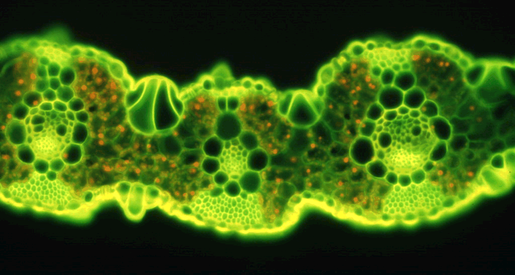

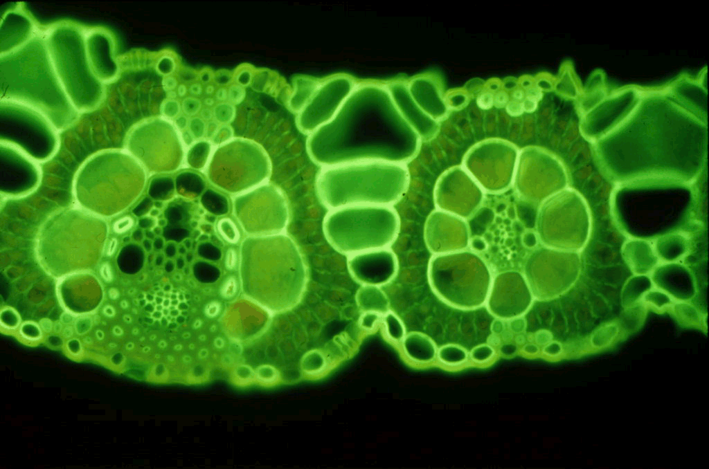

## C4 plants concentrate CO<sub>2</sub> around Rubisco *spatially*

- **New C4 pathway separates Calvin cycle from high O<sub>2</sub>**
- **C4 pathway: New enzyme, phosphoenolpyruvate carboxlylase (PEPC) fixes CO<sub>2</sub> to PEP (0 affinity for O<sub>2</sub>) to make malate (4C)**
  - C4 pathway occurs in mesophyll cell chloroplasts
  - malate sent to bundle sheath cells via plasmodesmata
- **Malate broken down to release CO<sub>2</sub> inside bundle sheath cells**
  - C3 pathway in bundle sheath cell chloroplasts
  - Calvin cycle (C3) runs with only CO~2 present
- **Hyper efficient with use of CO<sub>2</sub>**
  - BRAINSTORM: How does this impact stomatal behavior?

[figure not shown]

## C4 is a turbo-charged form of photosynthesis

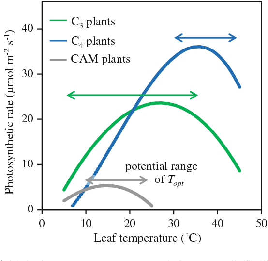

## Why is C4 photosynthesis not dominant?

- **Regeneration of PEP expensive (ATP)**
  - in addition to ATP needed for Calvin cycle
- **Where is needed ATP generated?**
  - high light requirements also means hotter/drier
- **Where should C4 plants live??**
  - efficiency vs dehydration for stomata
  - should be able to outcompete C3 plants

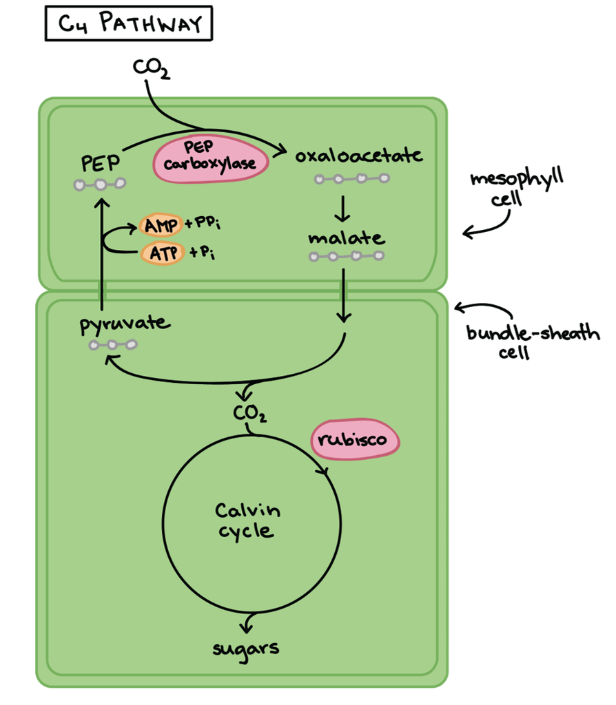

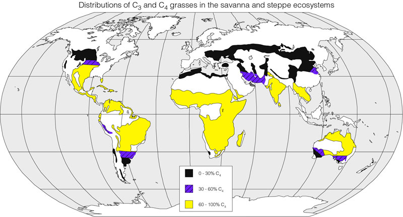

In hot conditions, the benefits of reduced photorespiration likely exceed the ATP cost of moving CO<sub>2</sub> from the mesophyll cell to the bundle-sheath cell

## C4 photosynthesis: Evolved independently 60-70 times

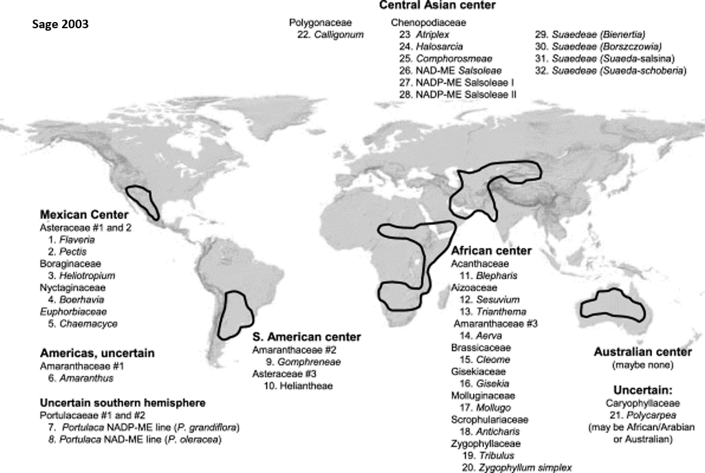

## C4 vs C3 vs principles of evolution

- **Recruitment of enzymes into new functions**
- **Massive shifts in distribution of parts**
  - proteins and organelles
- **Anatomical modifications to cell structure**
  - vein structure
- **Predict: In what type of plants would this most likely occur?**

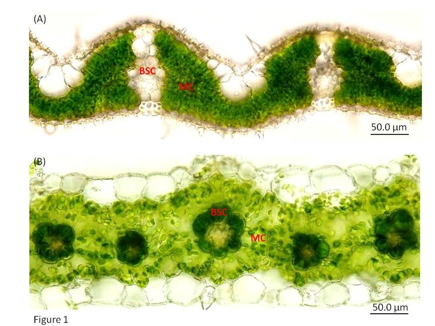

## Why are there virtually no C4 trees?

- **Is it difficult for trees to transition from C4→C4?**
  - long generation times
- **Why do C4 shrubs not evolve into C4 trees?**
  - they should have improved growth…
- **Was shade a problem?**
  - some Hawaiian C4 trees live in understory
- **C4 plants seem to have an issue growing tall**
  - ATP requirements of larger plants…

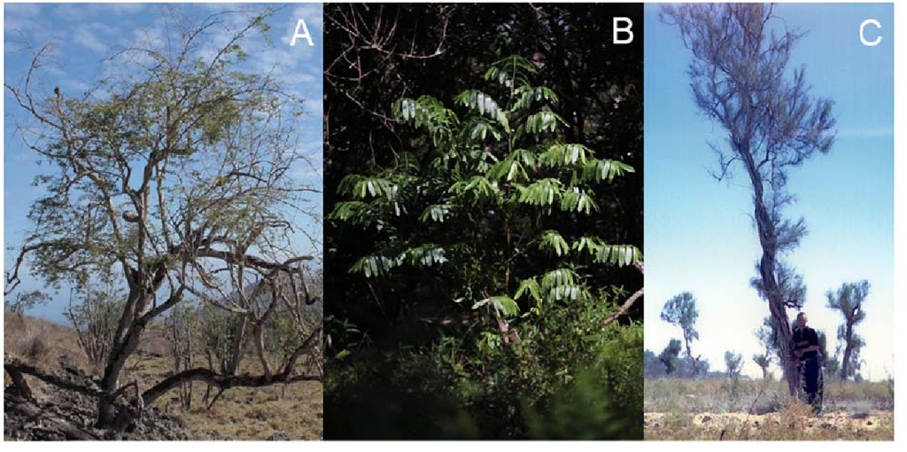

## Why C4 matters to you: Water-use-efficiency

- **Climate change impacts photosynthesis:**
  - ↑ CO<sub>2</sub>
  - ↑ temperatures
  - variable precipitation
  - variations in humidity
- **C4 plants can make the same amount of sugars as C3, with less water usage**
  - *more CO<sub>2</sub> assimilated per molecule of water loss*
  - ability to keep stomata closed more often
- **C3 & C4 plants should both benefit from extra CO<sub>2</sub>**
  - only works in C3 if enough H<sub>2</sub>0

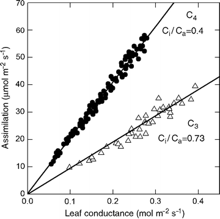

## Why C4 matters to you: Crops

- **C4 plants are economically important**
  - corn, sugarcane, sorghum & switchgrass
- **So are C3 crops**
  - beans, rice, wheat, potatoes (temperate crops)
- **Global water use is set to triple by 2050**
  - 70% to the agriculture sector
  - 50% transpired through stomata

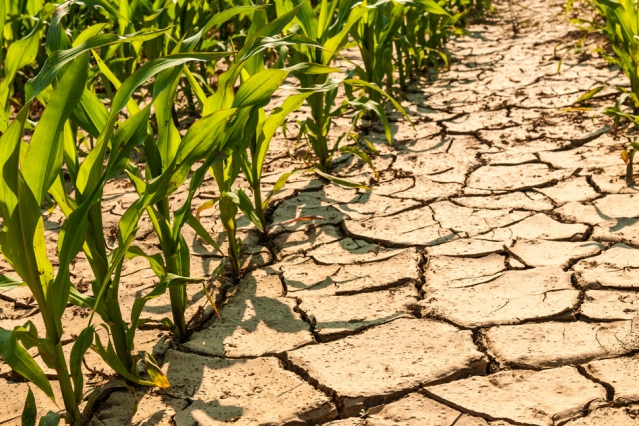

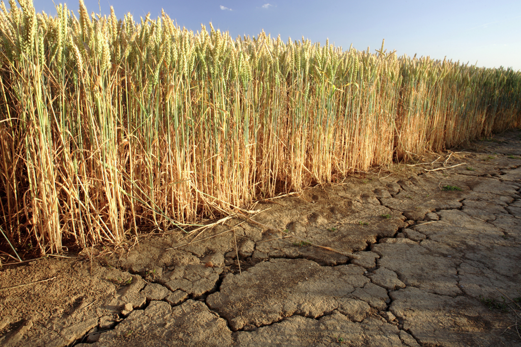

## Evolution of CAM photosynthesis (C4 pathway w/out BSC)

**Crassulacean acid metabolism (CAM) is an adatpation that improves conservation of water while still allowing photosynthesis**

**Metabolic pathway almost identical to C4 pathway but without structural modifications**

**Malate created from PEP and CO<sub>2</sub>, simply allowed to accumulate**

**Difference is with stomatal behavior**

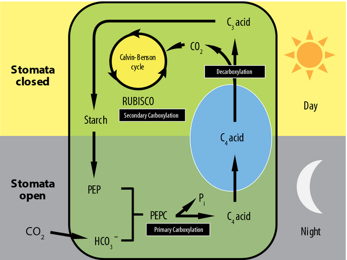

## CAM concentrates CO<sub>2</sub> around Rubisco *temporally*

- **Stomata open at night only**
  - malate produced in large quantities
    - CO<sub>2</sub> (stomata) + PEP
  - malate stored when Rubisco is inactive
- **C4 vs CAM = substitute function of bundle sheath cell (C4) for “night shift”**
- **Calvin cycle needs ATP, NADPH from light reactions but they are not stable enough to be stored for ‘night shift’**
- **Stomata close during day (no CO<sub>2</sub>, O<sub>2</sub> in) but stored malate (night shift) is broken down to release CO<sub>2</sub>**

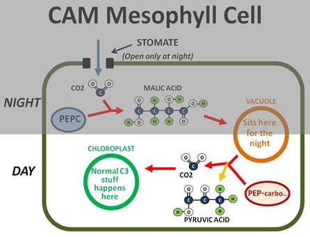

## Yes we CAM!!

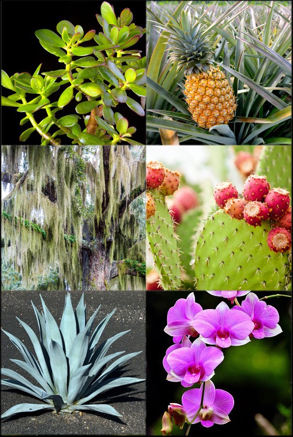

- **CAM evolved independently several times**
  - ~16,000 species
- **Exist in arid environments or habitats**
  - cacti
  - epiphytes
- **CAM is not very efficient, released CO<sub>2</sub> is used up within first few hours of daylight**
  - survival (harsher environments) over productivity
- **Are CAM plants fast or slow growing?**
- **Should CAM plants have many or few stomata?**

## C3 vs C4 vs CAM: Know advantages/disadvantages of each

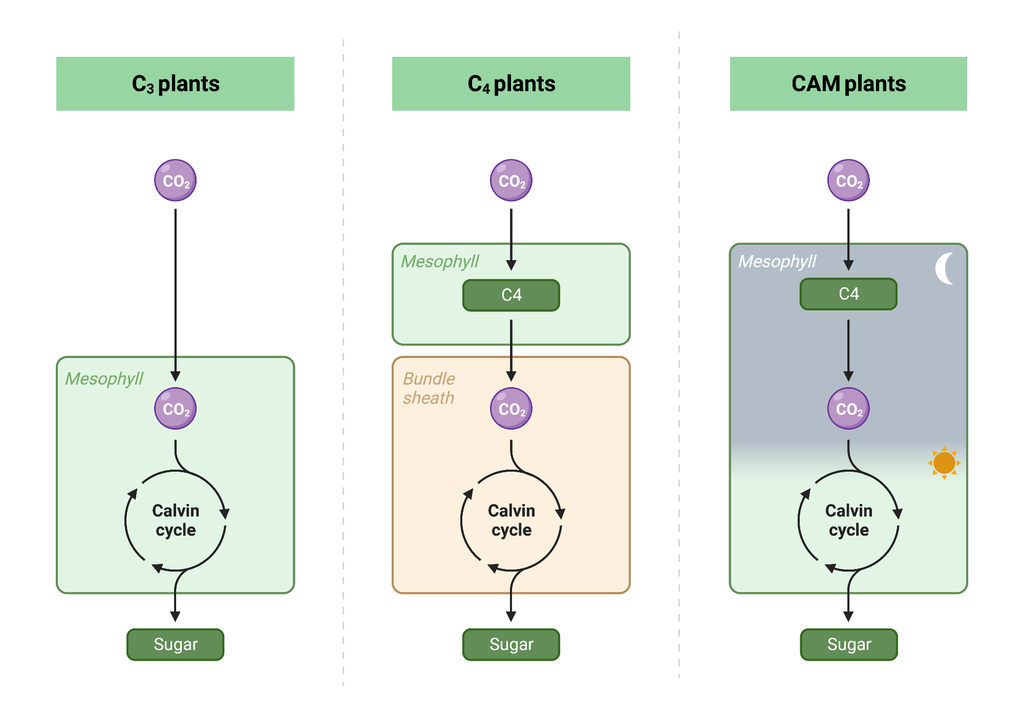

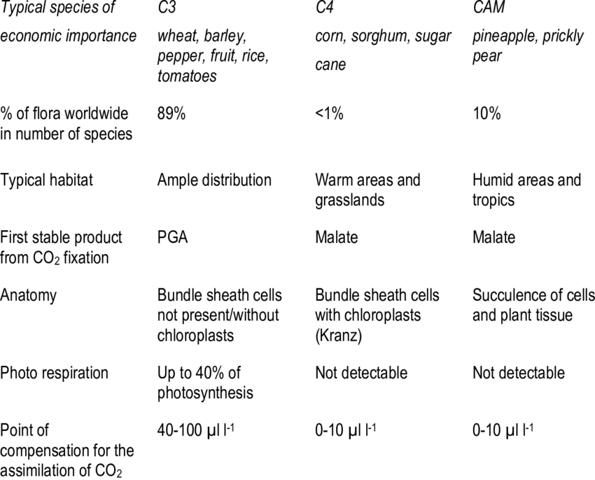